# Dean’s Dilemma

Parv Patni

December 10, 2017

## TASK 2b - Reading the dataset

```r
getwd()
```

```
## [1] "C:/Users/parvp/Desktop/data analytics internship"
```

```r
dean.df<-read.csv(paste("Data - Deans Dilemma.csv",sep=""))
head(dean.df)
```

```
##   SlNo Gender Gender.B Percent_SSC Board_SSC Board_CBSE Board_ICSE
## 1    1      M        0       62.00    Others          0          0
## 2    2      M        0       76.33      ICSE          0          1
## 3    3      M        0       72.00    Others          0          0
## 4    4      M        0       60.00      CBSE          1          0
## 5    5      M        0       61.00      CBSE          1          0
## 6    6      M        0       55.00      ICSE          0          1
##   Percent_HSC Board_HSC Stream_HSC Percent_Degree         Course_Degree
## 1       88.00    Others   Commerce          52.00               Science
## 2       75.33    Others    Science          75.48 Computer Applications
## 3       78.00    Others   Commerce          66.63           Engineering
## 4       63.00      CBSE       Arts          58.00            Management
## 5       55.00       ISC    Science          54.00           Engineering
## 6       64.00      CBSE   Commerce          50.00              Commerce
##   Degree_Engg Experience_Yrs Entrance_Test S.TEST Percentile_ET
```

[output cut: 20 more lines]

## TASK 2c - Summarize the dataset

```r
library(psych)
describe(dean.df)
```

```
##                     vars   n      mean        sd    median   trimmed
## SlNo                   1 391    196.00    113.02    196.00    196.00
## Gender*                2 391      1.68      0.47      2.00      1.72
## Gender.B               3 391      0.32      0.47      0.00      0.28
## Percent_SSC            4 391     64.65     10.96     64.50     64.76
## Board_SSC*             5 391      2.23      0.87      3.00      2.28
## Board_CBSE             6 391      0.29      0.45      0.00      0.24
## Board_ICSE             7 391      0.20      0.40      0.00      0.12
## Percent_HSC            8 391     63.80     11.42     63.00     63.34
## Board_HSC*             9 391      2.39      0.85      3.00      2.48
## Stream_HSC*           10 391      2.34      0.56      2.00      2.36
## Percent_Degree        11 391     62.98      8.92     63.00     62.91
## Course_Degree*        12 391      3.85      1.61      4.00      3.81
## Degree_Engg           13 391      0.09      0.29      0.00      0.00
## Experience_Yrs        14 391      0.48      0.67      0.00      0.36
## Entrance_Test*        15 391      5.85      1.35      6.00      6.08
## S.TEST                16 391      0.83      0.38      1.00      0.91
## Percentile_ET         17 391     54.93     31.17     62.00     56.87
## S.TEST.SCORE          18 391     54.93     31.17     62.00     56.87
## Percent_MBA           19 391     61.67      5.85     61.01     61.45
## Specialization_MBA*   20 391      1.47      0.56      1.00      1.42
## Marks_Communication   21 391     60.54      8.82     58.00     59.68
## Marks_Projectwork     22 391     68.36      7.15     69.00     68.60
## Marks_BOCA            23 391     64.38      9.58     63.00     64.08
## Placement*            24 391      1.80      0.40      2.00      1.87
## Placement_B           25 391      0.80      0.40      1.00      0.87
## Salary                26 391 219078.26 138311.65 240000.00 217011.50
##                          mad   min       max     range  skew kurtosis
## SlNo                  145.29  1.00    391.00    390.00  0.00    -1.21
## Gender*                 0.00  1.00      2.00      1.00 -0.75    -1.45
## Gender.B                0.00  0.00      1.00      1.00  0.75    -1.45
## Percent_SSC            12.60 37.00     87.20     50.20 -0.06    -0.72
## Board_SSC*              0.00  1.00      3.00      2.00 -0.45    -1.53
## Board_CBSE              0.00  0.00      1.00      1.00  0.93    -1.14
## Board_ICSE              0.00  0.00      1.00      1.00  1.52     0.31
## Percent_HSC            13.34 40.00     94.70     54.70  0.29    -0.67
## Board_HSC*              0.00  1.00      3.00      2.00 -0.83    -1.13
## Stream_HSC*             0.00  1.00      3.00      2.00 -0.12    -0.72
## Percent_Degree          8.90 35.00     89.00     54.00  0.05     0.24
## Course_Degree*          1.48  1.00      7.00      6.00  0.00    -1.08
```

[output cut: 26 more lines]

```
## Course_Degree*         0.08
## Degree_Engg            0.01
## Experience_Yrs         0.03
## Entrance_Test*         0.07
## S.TEST                 0.02
## Percentile_ET          1.58
## S.TEST.SCORE           1.58
## Percent_MBA            0.30
## Specialization_MBA*    0.03
## Marks_Communication    0.45
## Marks_Projectwork      0.36
## Marks_BOCA             0.48
## Placement*             0.02
## Placement_B            0.02
## Salary              6994.72
```

## TASK 3a

calculate the median salary of all the students in the data sample

```r
median(dean.df$Salary)
```

```
## [1] 240000
```

## TASK 3b

calculate the percentage of students who were placed, correct to 2 decimal places.

```r
a<-round(prop.table(table(dean.df$Placement))*100, digits = 2)
a[2]
```

```
## Placed
##   79.8
```

## TASK 3c

create a dataframe called placed, that contains a subset of only those students who were successfully placed.

```r
placed <- dean.df[which(dean.df$Placement_B == 1),]
```

## TASK 3d

find the median salary of students who were placed.

```r
median(placed$Salary)
```

```
## [1] 260000
```

## TASK 3e

create a table showing the mean salary of males and females, who were placed.

```r
aggregate(placed$Salary, by=list(gender = placed$Gender), mean)
```

```
##   gender        x
## 1      F 253068.0
## 2      M 284241.9
```

## TASK 3f

generate histogram showing a breakup of the MBA performance of the students who were placed

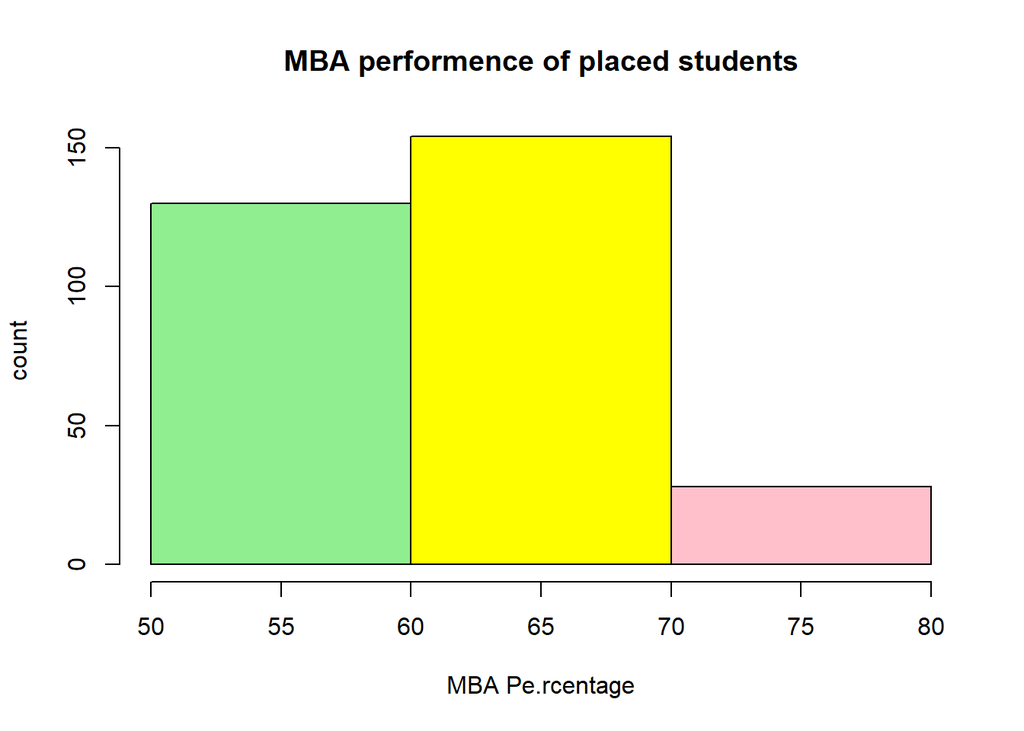

```r
hist(placed$Percent_MBA, breaks = 2, ylab = "count", xlab="MBA Pe.rcentage", main="MBA performence of placed students", col=c("lightgreen", "yellow", "pink"))
```

##TASK 3g Create a dataframe called notplaced, that contains a subset of only those students who were NOT placed after their MBA.

```r
notplaced=dean.df[which(dean.df$Placement_B==0),]
```

## TASK 3h

Draw two histograms side-by-side, visually comparing the MBA performance of Placed and Not Placed students, as follows:

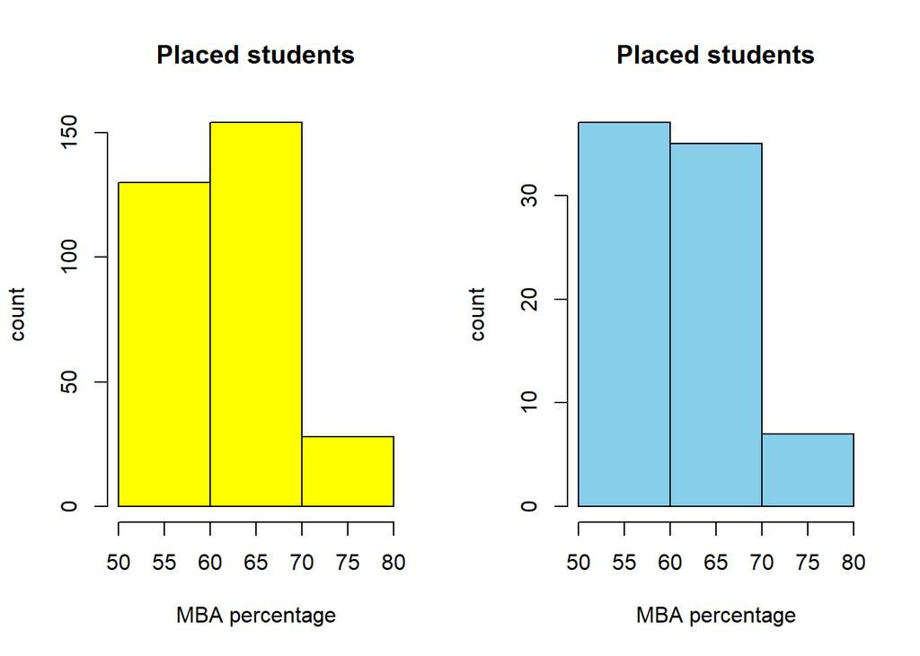

```r
par(mfrow=c(1,2))
with(placed, hist(placed$Percent_MBA, main = "Placed students",xlab = "MBA percentage",ylab="count", breaks = 2, col = "yellow"))
with(notplaced, hist(notplaced$Percent_MBA, main = "Placed students",xlab = "MBA percentage",ylab="count", breaks = 2, col = "skyblue"))
```

##TASK 3i draw two boxplots, one below the other, comparing the distribution of salaries of males and females who were placed, as follows:

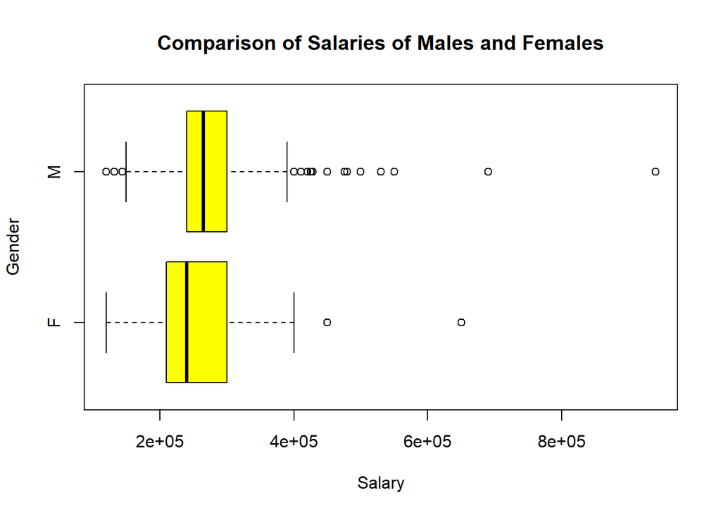

```r
boxplot(placed$Salary ~ placed$Gender, main="Comparison of Salaries of Males and Females",
              col=c("yellow"),horizontal=TRUE,
              xlab="Salary", ylab = "Gender" )
```

## TASK 3j

Create a dataframe called placedET, representing students who were placed after the MBA and who also gave some MBA entrance test before admission into the MBA program.

```r
placedET<- dean.df[which(dean.df$S.TEST==1 & dean.df$Placement_B==1),]
```

## TASK 3k

Draw a Scatter Plot Matrix for 3 variables – {Salary, Percent_MBA, Percentile_ET} using the dataframe placedET.

```r
library(car)
```

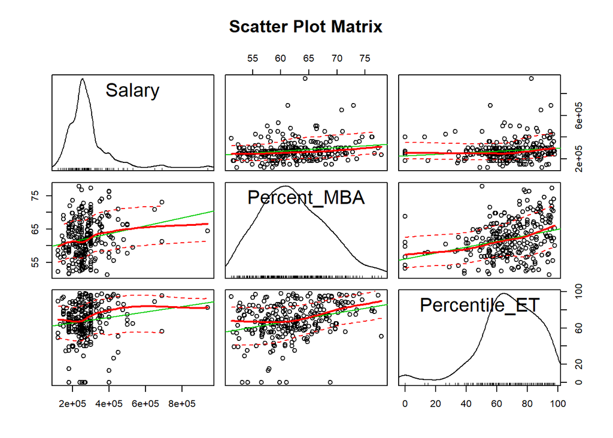

```r
scatterplotMatrix(formula = ~ Salary + Percent_MBA + Percentile_ET, data = placedET, main = "Scatter Plot Matrix")
```